# Capstone Quiz I

Complete all **Exercises**, and submit answers to **Questions** on the Coursera platform.

This initial quiz will concern exploratory data analysis (EDA) of the Ames Housing dataset. EDA is essential when working with any source of data and helps inform modeling.

First, let us load the data:

```r
load("ames_train.Rdata")
#https://github.com/StatsWithR/statsr/blob/master/R/ames.R
```

```r
library(PairedData)
library(tidyverse)
library(statsr)
library(dplyr)
library(ggplot2)
```

1. Which of the following are the three variables with the highest number of missing observations?
   1. `Misc.Feature`, `Fence`, `Pool.QC`
   2. [x] `Misc.Feature`, `Alley`, `Pool.QC`
   3. `Pool.QC`, `Alley`, `Fence`
   4. `Fireplace.Qu`, `Pool.QC`, `Lot.Frontage`

```r
# type your code for Question 1 here, and Knit
ames_train %>%
  select_if(function(x) any(is.na(x))) %>%
  summarise_each(funs(sum(is.na(.)))) -> extra_NA
```

```
## `summarise_each()` is deprecated.
## Use `summarise_all()`, `summarise_at()` or `summarise_if()` instead.
## To map `funs` over all variables, use `summarise_all()`
```

```r
d <- t(extra_NA)
d[order(-d),]
```

```
##        Pool.QC   Misc.Feature          Alley          Fence   Fireplace.Qu
##            997            971            933            798            491
##   Lot.Frontage  Garage.Yr.Blt    Garage.Qual    Garage.Cond    Garage.Type
##            167             48             47             47             46
##  Garage.Finish      Bsmt.Qual      Bsmt.Cond  Bsmt.Exposure BsmtFin.Type.1
##             46             21             21             21             21
## BsmtFin.Type.2   Mas.Vnr.Area   BsmtFin.SF.1   BsmtFin.SF.2    Bsmt.Unf.SF
##             21              7              1              1              1
##  Total.Bsmt.SF Bsmt.Full.Bath Bsmt.Half.Bath    Garage.Cars    Garage.Area
##              1              1              1              1              1
```

2. How many categorical variables are coded in R as having type `int`? Change them to factors when conducting your analysis.
   1. 0
   2. [false] 1
   3. [x] 2
   4. 3

```r
# type your code for Question 2 here, and Knit
ames_train %>%
  select_if(function(x) any(is.integer(x))) %>%
  summarise_each(funs(sum(is.integer(.)))) -> int_var
```

```
## `summarise_each()` is deprecated.
## Use `summarise_all()`, `summarise_at()` or `summarise_if()` instead.
## To map `funs` over all variables, use `summarise_all()`
```

```r
d <- t(int_var)
d[order(-d),]
```

```
##             PID            area           price     MS.SubClass
##               1               1               1               1
##    Lot.Frontage        Lot.Area    Overall.Qual    Overall.Cond
##               1               1               1               1
##      Year.Built  Year.Remod.Add    Mas.Vnr.Area    BsmtFin.SF.1
##               1               1               1               1
##    BsmtFin.SF.2     Bsmt.Unf.SF   Total.Bsmt.SF     X1st.Flr.SF
##               1               1               1               1
##     X2nd.Flr.SF Low.Qual.Fin.SF  Bsmt.Full.Bath  Bsmt.Half.Bath
##               1               1               1               1
##       Full.Bath       Half.Bath   Bedroom.AbvGr   Kitchen.AbvGr
##               1               1               1               1
##   TotRms.AbvGrd      Fireplaces   Garage.Yr.Blt     Garage.Cars
##               1               1               1               1
##     Garage.Area    Wood.Deck.SF   Open.Porch.SF  Enclosed.Porch
##               1               1               1               1
##     X3Ssn.Porch    Screen.Porch       Pool.Area        Misc.Val
##               1               1               1               1
##         Mo.Sold         Yr.Sold
##               1               1
```

```r
ames_train$MS.SubClass <- as.factor(ames_train$MS.SubClass)
```

3. In terms of price, which neighborhood has the highest standard deviation?
   1. [x] `StoneBr`
   2. `Timber`
   3. `Veenker`
   4. `NridgHt`

```r
# type your code for Question 3 here, and Knit
ames_train %>% group_by(Neighborhood) %>% summarise(std=sd(price)) -> price_sd
price_sd[order(-price_sd$std),]
```

```
## # A tibble: 27 x 2
##    Neighborhood     std
##    <fct>          <dbl>
##  1 StoneBr      123459.
##  2 NridgHt      105089.
##  3 Timber        84030.
##  4 Veenker       72545.
##  5 Crawfor       71268.
##  6 GrnHill       70711.
##  7 Somerst       65199.
##  8 Edwards       54852.
##  9 CollgCr       52786.
## 10 SawyerW       48354.
## # ... with 17 more rows
```

4. Using scatter plots or other graphical displays, which of the following variables appears to be the best single predictor of `price`?
   1. `Lot.Area`
   2. `Bedroom.AbvGr`
   3. [x] `Overall.Qual`
   4. `Year.Built`

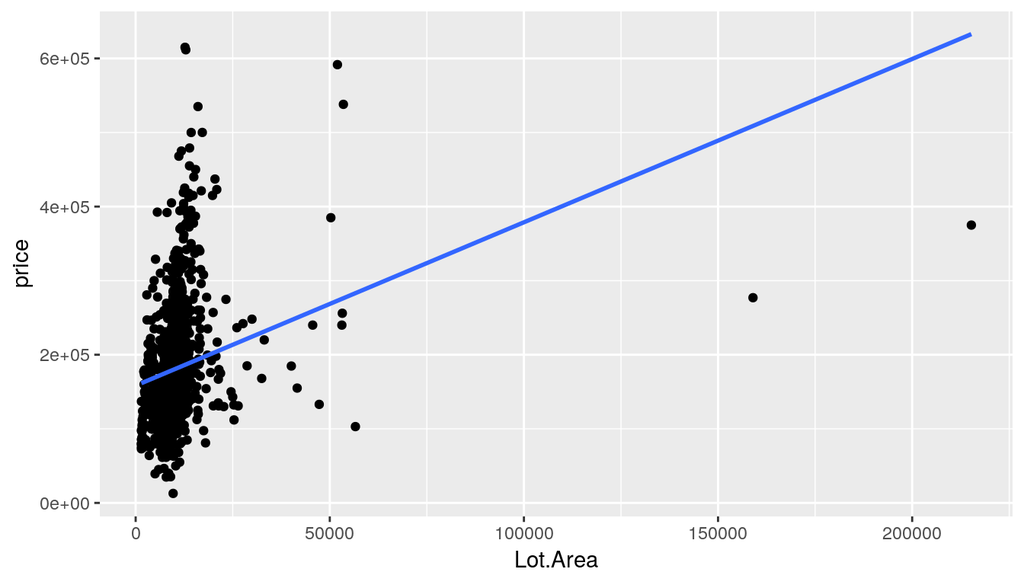

```r
# type your code for Question 4 here, and Knit
ggplot(ames_train, aes(x=Lot.Area,y=price)) + geom_point() + stat_smooth(method = "lm", se = FALSE)
```

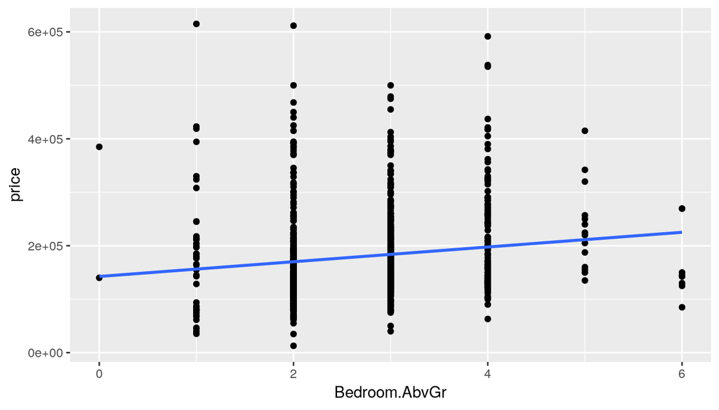

```r
ggplot(ames_train, aes(x=Bedroom.AbvGr,y=price)) + geom_point() + stat_smooth(method = "lm", se = FALSE)
```

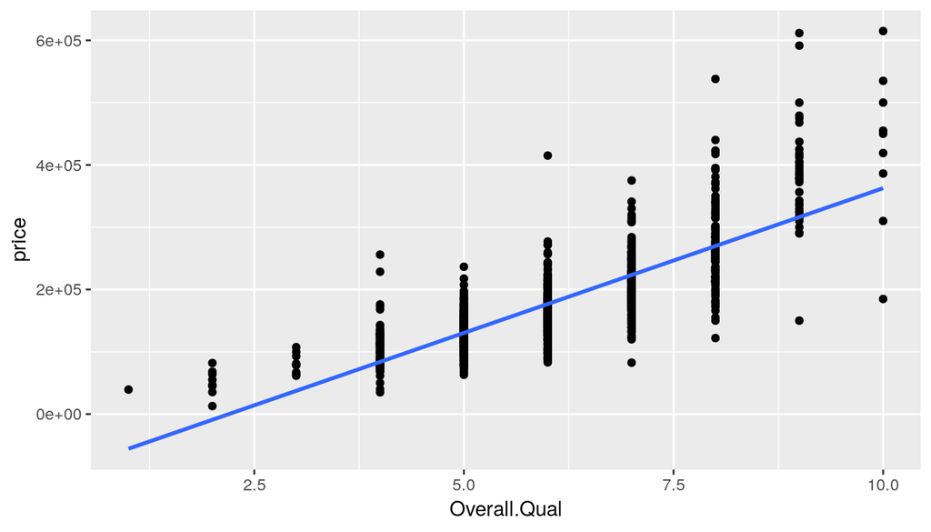

```r
ggplot(ames_train, aes(x=Overall.Qual,y=price)) + geom_point() + stat_smooth(method = "lm", se = FALSE)
```

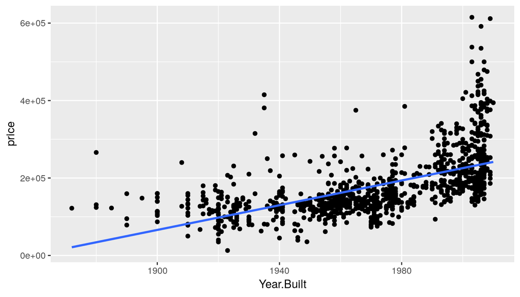

```r
ggplot(ames_train, aes(x=Year.Built,y=price)) + geom_point() + stat_smooth(method = "lm", se = FALSE)
```

```r
cor(ames_train$Overall.Qual, ames_train$price)
```

```
## [1] 0.8017491
```

```r
cor(ames_train$Year.Built, ames_train$price)
```

```
## [1] 0.5774753
```

5. Suppose you are examining the relationship between `price` and `area`. Which of the following variable transformations makes the relationship appear to be the most linear?
   1. Do not transform either `price` or `area`
   2. Log-transform `price` but not `area`
   3. Log-transform `area` but not `price`
   4. [x] Log-transform both `price` and `area`

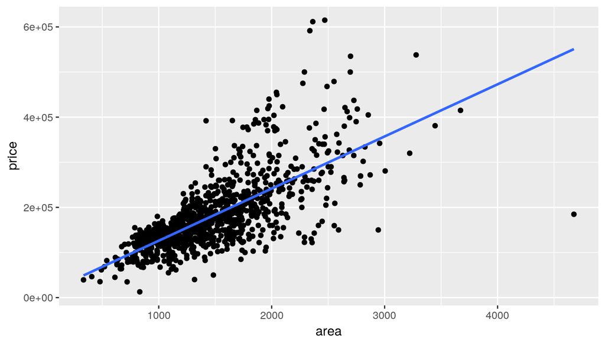

```r
# type your code for Question 5 here, and Knit
ggplot(ames_train, aes(x=area,y=price)) + geom_point() + stat_smooth(method = "lm", se = FALSE)
```

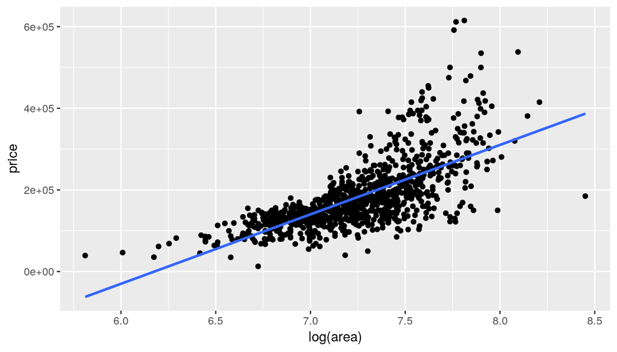

```r
ggplot(ames_train, aes(x=log(area),y=price)) + geom_point() + stat_smooth(method = "lm", se = FALSE)
```

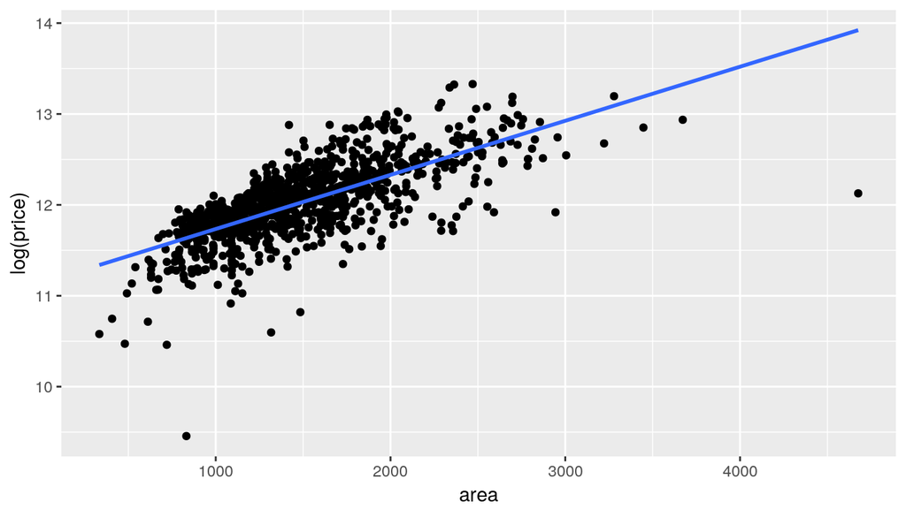

```r
ggplot(ames_train, aes(x=area,y=log(price))) + geom_point() + stat_smooth(method = "lm", se = FALSE)
```

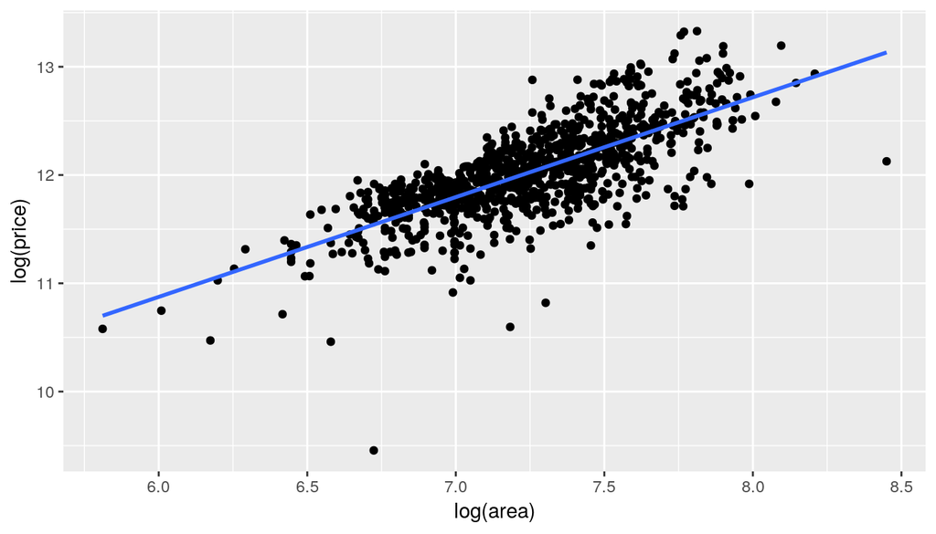

```r
ggplot(ames_train, aes(x=log(area),y=log(price))) + geom_point() + stat_smooth(method = "lm", se = FALSE)
```

```r
cor(ames_train$area, ames_train$price)
```

```
## [1] 0.7127375
```

```r
cor(log(ames_train$area), ames_train$price)
```

```
## [1] 0.7006098
```

```r
cor(ames_train$area, log(ames_train$price))
```

```
## [1] 0.714812
```

```r
cor(log(ames_train$area), log(ames_train$price))
```

```
## [1] 0.7393174
```

```r
# type your code for Question 6 here, and Knit
alfa = 9
beta = 1

ames_train %>% filter(Garage.Cars > 0) %>% count() -> x
ames_train %>% filter(!is.na(Garage.Cars)) %>% count() -> n

palfa = alfa + x
pbeta = beta + n - x
c(palfa, pbeta)
```

```
## $n
## [1] 962
##
## $n
## [1] 47
```

7. Which of the following statements is true about the dataset?
   1. Over 30 percent of houses were built after the year 1999.
   2. The median housing price is greater than the mean housing price.
   3. [x] 21 houses do not have a basement.
   4. 4 houses are located on gravel streets.

```r
# type your code for Question 7 here, and Knit
ames_train %>% filter(Year.Built>1999) %>% count() -> after1999
ames_train %>% filter(!is.na(Year.Built)) %>% count() -> total
after1999/total
```

```
##       n
## 1 0.272
```

```r
ames_train %>% summarize(mean=mean(price), median=median(price), median_greater_than_mean=median(price)>mean(price))
```

```
## # A tibble: 1 x 3
##      mean median median_greater_than_mean
##     <dbl>  <dbl> <lgl>
## 1 181190. 159467 FALSE
```

```r
ames_train %>% filter(Total.Bsmt.SF==0) %>% count()
```

```
## # A tibble: 1 x 1
##       n
##   <int>
## 1    21
```

```r
ames_train %>% group_by(Street) %>% count()
```

```
## # A tibble: 2 x 2
## # Groups:   Street [2]
##   Street     n
##   <fct>  <int>
## 1 Grvl       3
## 2 Pave     997
```

8. Test, at the $\alpha = 0.05$ level, whether homes with a garage have larger square footage than those without a garage.
   1. [x] With a p-value near 0.000, we reject the null hypothesis of no difference.
   2. With a p-value of approximately 0.032, we reject the null hypothesis of no difference.
   3. With a p-value of approximately 0.135, we fail to reject the null hypothesis of no difference.
   4. With a p-value of approximately 0.343, we fail to reject the null hypothesis of no difference.

```r
# type your code for Question 8 here, and Knit
ames_train$hasGarage <- ifelse(ames_train$Garage.Area>0, 1, 0)
inference(y = area, x = hasGarage, data = ames_train, statistic = "mean", type = "ht", alternative="less", method = "theoretical")
```

```
## Response variable: numerical
## Explanatory variable: categorical (2 levels)
## n_0 = 46, y_bar_0 = 1145.0435, s_0 = 445.1805
## n_1 = 953, y_bar_1 = 1492.2508, s_1 = 502.738
## H0: mu_0 =  mu_1
## HA: mu_0 < mu_1
## t = -5.134, df = 45
## p_value = < 0.0001
```

[figure not shown]

9. For homes with square footage greater than 2000, assume that the number of bedrooms above ground follows a Poisson distribution with rate $\lambda$. Your prior on $\lambda$ follows a Gamma distribution with mean 3 and standard deviation 1. What is your posterior mean and standard deviation for the average number of bedrooms in houses with square footage greater than 2000 square feet?
   1. Mean: 3.61, SD: 0.11
   2. [x] Mean: 3.62, SD: 0.16
   3. Mean: 3.63, SD: 0.09
   4. Mean: 3.63, SD: 0.91

```r
# type your code for Question 9 here, and Knit
lambda <- 3
sigma_sq <- 1
b <- lambda/sigma_sq
a <- lambda * b

ames_train %>% filter(area > 2000) %>% summarise(sum=sum(Bedroom.AbvGr)) -> sum_x
ames_train %>% filter(area > 2000) %>% count() -> n
a_star <- a + sum_x
b_star <- b + n
lambda_star <- a_star / b_star
sigma_star <- sqrt(a_star / b_star^2)
print(paste("Mean: ",lambda_star,", SD: ",sigma_star))
```

```
## [1] "Mean:  3.61702127659574 , SD:  0.160164394193421"
```

10. When regressing $\log$(`price`) on $\log$(`area`), there are some outliers. Which of the following do the three most outlying points have in common?
    1. They had abnormal sale conditions.
    2. They have only two bedrooms.
    3. They have an overall quality of less than 3.
    4. [x] They were built before 1930.

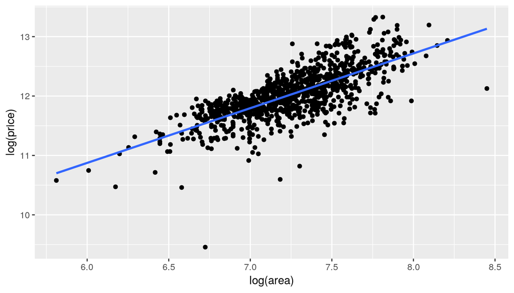

```r
# type your code for Question 10 here, and Knit
fit <- lm(log(price)~log(area), data=ames_train)
ggplot(ames_train, aes(x=log(area),y=log(price))) + geom_point() + stat_smooth(method = "lm", se = FALSE)
```

```r
ames_train$stdres <- stdres(fit)
ames_train$stdres_abs <- abs(stdres(fit))
ames_train$stdres_gt3 <- abs(stdres(fit)) > 3
ames_train[which(ames_train$stdres_gt3 == TRUE), c('Bedroom.AbvGr','Overall.Qual', 'Year.Built','Sale.Condition','stdres_abs')] %>% arrange(desc(stdres_abs)) %>% head(n=3)
```

```
## # A tibble: 3 x 5
##   Bedroom.AbvGr Overall.Qual Year.Built Sale.Condition stdres_abs
##           <int>        <int>      <int> <fct>               <dbl>
## 1             2            2       1923 Abnorml              7.37
## 2             3            4       1920 Normal               4.83
## 3             3            4       1910 Abnorml              4.43
```

```r
plot
```

[output not shown]

11. Which of the following are reasons to log-transform `price` if used as a dependent variable in a linear regression?
    1. [x] `price` is right-skewed.
    2. `price` cannot take on negative values.
    3. `price` can only take on integer values.
    4. [false] Both a and b.

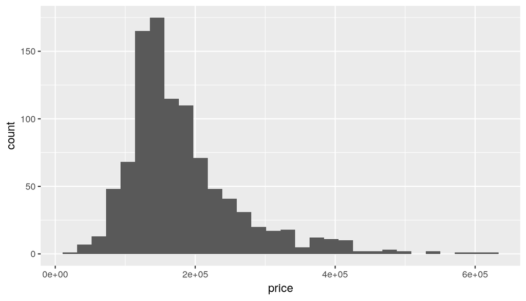

```r
# type your code for Question 11 here, and Knit
ggplot(ames_train, aes(x=price)) +  geom_histogram()
```

12. How many neighborhoods consist of only single-family homes? (e.g. `Bldg.Type` = `1Fam`)
    1. 0
    2. 1
    3. 2
    4. [x] 3

```r
# type your code for Question 12 here, and Knit
ames_train %>% group_by(Neighborhood) %>% summarise(proportion=mean(Bldg.Type == "1Fam")) %>% filter(proportion==1)
```

```
## # A tibble: 3 x 2
##   Neighborhood proportion
##   <fct>             <dbl>
## 1 ClearCr               1
## 2 NoRidge               1
## 3 Timber                1
```

13. Using color, different plotting symbols, conditioning plots, etc., does there appear to be an association between $\log$(`area`) and the number of bedrooms above ground (`Bedroom.AbvGr`)?
    1. [x] Yes
    2. No

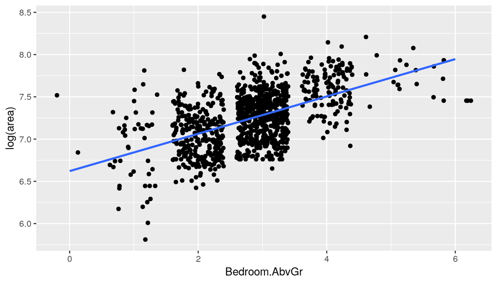

```r
# type your code for Question 13 here, and Knit
ggplot (ames_train, aes(x=Bedroom.AbvGr, y=log(area))) + geom_jitter() + stat_smooth(method = "lm", se = FALSE)
```

```r
cor(ames_train$Bedroom.AbvGr, log(ames_train$area))
```

```
## [1] 0.5457625
```

```r
fit <- lm(formula = log(area) ~ Bedroom.AbvGr, data = ames_train)
summary(fit)
```

```
##
## Call:
## lm(formula = log(area) ~ Bedroom.AbvGr, data = ames_train)
##
## Residuals:
##      Min       1Q   Median       3Q      Max
## -1.03122 -0.22160  0.00907  0.19103  1.16612
##
## Coefficients:
##               Estimate Std. Error t value Pr(>|t|)
## (Intercept)    6.62150    0.03142  210.75   <2e-16 ***
## Bedroom.AbvGr  0.22086    0.01073   20.58   <2e-16 ***
## ---
## Signif. codes:  0 '***' 0.001 '**' 0.01 '*' 0.05 '.' 0.1 ' ' 1
##
## Residual standard error: 0.2828 on 998 degrees of freedom
## Multiple R-squared:  0.2979, Adjusted R-squared:  0.2972
## F-statistic: 423.4 on 1 and 998 DF,  p-value: < 2.2e-16
```

14. Of the people who have unfinished basements, what is the average square footage of the unfinished basement?
    1. 590.36
    2. [x] 595.25
    3. 614.37
    4. 681.94

```r
# type your code for Question 14 here, and Knit
ames_train %>% filter(!is.na(Bsmt.Unf.SF), Bsmt.Unf.SF>0) %>% summarise(mean=mean(Bsmt.Unf.SF))
```

```
## # A tibble: 1 x 1
##    mean
##   <dbl>
## 1  595.
```